# Generalized Random Forest (GRF)

[The notebook with the codes](https://colab.research.google.com/drive/10__8At4OYIgQZhCe7WJZpFZFJidYcy4L?usp=sharing)

In a lot of application such as in marketing and medicine people are interested in verifying causal relationships such as treatment effects. However, in comparison to Angrist & Imbens (1991) the goal is not to estimate the overall treatment effect but the heterogeneous treatment effect, where the Generalized Random Forest (Athey & Tibshirani & Wager, 2018) provides a new approach based on the approaches of causal tree and causal forest introduced by Wager & Athey (2018).

In this notebook we want to focus on how to estimate the heterogeneous treatment effect by using the Genralized Random Forest. Therefore, in the first part we will give some information about the basic and the early approach of Athey & Imbens about the causal tree and causal forest which contibuted to the creation of this novel approach, followed by the basic assumptions which are taken for the generalized random forest and the algorithm. In the following sections, the empirical work on both real life and synthetic data will be shared in order to discuss overall performance of the approach. Further study on the approach in Oprescu & Syrgkanis & Wu (2019) will also be mentioned for showing the suggestions for further improvements on the approach.

## Introduction

In many application nowadays it is important to determine the causal relatioship between features also known as treatment effect. One application can be found in the marketing field where market researchers try to analyze to what extent advertisement (treatment) influences sales. To calculate the treatment effect the observations are divided into treatment and control group. Whereas the treatment group gets the advertisement and the control group not. The issue with this setting is that it is not possible to observe the individual treatment. Therefore for example Angrist & Imbens (1991) tried to estimate the treatment effect. To get a better result often the conditional average treatment effect (CATE) estimation is used which can be described with following formulas,

$\tau (x)= E[Y_i(1)-Y_i(0)\vert X_i$=x] ,

where let $Y(1)$ be the Output of the treatment group and $Y(0)$ the output of the control group and $X_i$ a K-component vector of features, covariates or pretreatment variables which are not affected by the treatment. Whereas the common issue in calculating the treatment effect is that only $Y(1)$ or $Y(0)$ can be observed, Thereby, the treatment effect is estimated for different subgroups whereas the subgroups are as heterogeneous as possible.

There are different methods to estimate the heterogeneous treatment effect such as tree based methods where the Generalized Random Forest is one novel approach based on the model of Random Forest by Breiman (2001) and causal tree and causal forest by Wager & Athey (2018).

## Causal Tree and Causal Forest

Causal Tree is the base approach for the Generalized Random Forest. The paper of Athey & Imbens (2016) describes two main problems such as how to estimate heterogeneity by covariates or features in causal effects in experimental studies. The problem with classic nonparametric methods such as kernel method is that these approaches only work well with a small amount of covariates. Causal tree enables to construct a valid confidence interval for treatment effect even with a high amount of covariates. The two main points in creating a tree are the partitioning rule and handling with data, in which parts they are divided and used for what.

**Unconfoundeness**

$W_i⊥(Y_i(0),Y_i(1))\vert X_i$ ,

Let $W_i \in \{0,1\}$ be the binary indicator for treatment where $W_i=1$ indicates that unit i receives the treatment and $W_i=0$ indicates that unit i is in the control group and do not receive any treatment. Unconfoundeness or ingnorability is an assumption which is given for randomized experiment. Without unconfoundeness it is not possible to estimate the heterogeneous treatment effect ($\tau$) from the observed data ($W_i,X_i,Y_i$) without setting further restrictions for data-generating distribution. According to Rosenbaum & Rubin (1983) unconfoundeness means that the treatment assignment $W_i$ is independent of the outcomes for $Y_i$ conditional on $X_i$. In other words, every unit in the population has the opportunity to get each treatment indendent of their output and their characteristics(Rosenbaum & Rubin, 1983). Through this assumption it is possible to get access to a simple unbiased estimator for the treatment effect (Athey & Wager, 2018).

**Honest Estimation**

One important approach of causal tree is honest estimation. Conventional methods split the data into training and test set. Whereas in causal tree and causal forest to get a honest estimation, the training set is splitted again into training and estimation set. The training set is used to partition the tree into different leaves and the estimation set estimate the effects which are the point of interest within the leaves.

**Honest Spliting Criteria for Treatment Effects**

In the paper of Athey & Imbens (2016) the honest target is the mean square error (MSE) criteria, which can be defined in a treatment setting as:

$MSE_{\tau}(S^{te},S^{est},\pi)\equiv \frac{1}{\#(S^{te})}\sum_{i\epsilon S^{te}}\{(\tau_i - \hat{\tau}(X_i;S^{{est}},\pi))^2-\tau_i^2\}$ with $\hat{\tau}(x;S,\pi)\equiv\hat{\mu}(1,x;S,\pi)-\hat{\mu}(0,x;S,\pi)$,

where $\hat{\mu}(1,x;S,\pi)$ stands for the treated observations and $\hat{\mu}(1,x;S,\pi)$ for non-treated ones. By building the difference the treatment effect is estimated.

The goal is to to build an algorithm which maximizes the honest criterion which is the negative MSE expression. After several steps of expanding the EMSE and estimating the variance of the conditional mean function leads to an unbiased estimator for $EMSE_{\tau} (\pi)$.

$-\hat{EMSE}_{\tau}(S^{tr},N^{est},\pi)\equiv \frac{1}{N^{tr}}\sum_{i\epsilon S^{tr}} hat{\tau}^2(X_i;S^{tr},\pi)-(\frac{1}{N^{tr}}+\frac{1}{N^{est}})\cdot \sum_{l \epsilon \pi}(\frac{S^2_{S^{tr}_{treat}}(l)}{p}+\frac{S^2_{S^{tr}_{control}}(l)}{1-p})$,

where $S^2$ is the variance of a leaf and N the amount of observations of the group accordingly sample.

The main difference between the conventional CART algorithm and the honest one is that the variance is considered. This criteria penalizes partition that leads to a higher variance in leaf estimation and rewards splittings which increase the heterogeneity in treatment effects.

**From Causal Tree to Causal Forest**

To create a causal forest an ensemble of an amount of B trees is needed. Thereby any indidual causal tree is build by an subsample of the training set. The treatment effect is then calculated by aggregating the treatment effect of every single tree and average it with the number of trees (B).

$\tau(x)=\frac{1}{B}\sum_{b=1}^{B}\tau_{b}(x)$

Based on the facts that individual tree $\tau_{b}(x)$ has a low bias but a high variance the prediction can be stabilized through the usage of an ensemble model.

## Generalized Random Forest

According to Athey & Tibshirani & Wager (2018) the goal is to build with the algorithm a non-parametric estimators that has the stability, ease of use and flexibility adaption to different forms like the regression forest and it can be used in the wiede range of statistical settings. As mentioned above the causal forest can decrease the variance but the bias in treatment effect can not be reduced by this method. The generalized forest is a type of adaptive locally weighted estimators that uses first a forest to calcuate the weighted set of neighbors for each test point. Afterwards a plug-in version of the estimating equation using these neighbors are solved. Instead of buiding a ensemble model of all trees each point in estimation is given a specific importance on the weighting according to their neighborhood relationships to particular test point. Furthermore, instead of using the optimization criteria such as MSE in causal forest, the generalized random forest uses the gradient approch.

**Assumptions**

There are six different assmptions mentioned in the paper of Athey & Tibshirani & Wager (2018) in the section of Asymtptic Analysis. We focused in our notebook only on the following three, because those are the most important ones.

**Assumption 1: Unconfoundness**

The first one is the unconfoundness which is already mentioned as assumption for building the causal tree and causal forest. The main point is that the treatment assignment is independent of the outcomes, which is given in every randomized experiment.

**Assumption 2: Lipschitz x-signal**

For fixed values of ($\theta, v$), we assume that $M_{\theta,v}(x)$ defined as scoring function with the formula:

$M_{\theta,v}(x):=\mathbb{E}[\psi_{\theta,v}(O)\vert X=x]$

is Lipschitz continous in x. The Lipschitz continuity is a strong form of uniform continuity for functions. The Lipschitz continuity function limits how fast the function can change. For that a real number exist such that for every pair of points on the graph of this function, in our case the scoring function, the absolute value of the slope of the line connecting them is not grater than this real number.

**Assumption 3: Smooth identification** The Assumpion of smooth identification explained that if x is fixed that the scoring function $M$ is twice continously differentiable in ( $\theta ,v$) with a bounded second derivative. That means nothing else than that it needs to be possible to build the second derivative of the M-function but not the third one. If this is fulfilled then the second derivative is uniformly bounded.

**Adaptive Neighborhood**

The main difference between generalized random forest and non-parametric regression techniques is that recursive partitioning on subsamples is used to generate weights ($\alpha_i(x)$) and also these similarity weights are used to estimating the theta(x) which is then used to fit the target with an empirical version of the estimating equation:

$(\hat{\theta}(x),\hat{v}(x)) \epsilon argmin_{\theta,v}\{{ \vert\vert \sum_{i=1}^{n} \alpha_i(x) \psi_{\theta,v}(O_i)\vert\vert_{2}\}}$,

which means nothing else that the $\theta$ is calculated such that the minimizing condition is satisified.

The goal is to minimize the scoring function which can be seen in our case as loss function based on the weighing $\alpha$. Whereas these weights can be chosen by some deterministic kernel functions (Athey, Tib…) for generalized random forest are obtained by averaging neighborhoods implicitly produced by different trees. Therefore first a number of trees B is grown where for each tree contains of leaves $L_b(x)$. The weights are captured by how many training examples fell into the same leave as x which can be defined with this formula:

$\alpha_{bi}(x)=\frac{1(\{X_i \epsilon L_b(x)\})}{\vert L_b(x) \vert}$, $\alpha_i(x)=\frac{1}{B}\sum _{b=1}^{B} \alpha_{bi}((x)$

The sum of all weights from the estimting points sum up to 1 which defines the forest-based adaptive neighborhood. The weights for one point are calculated by the formula above. Through setting the forest-based adaptive neighborhood not only points who lies on the same leaf with the test point x are considered during the CATE estimation such as in the other tree based algorithm but through the weighting all points are considered.

**Splitting criteria**

During the splitting the focus is on the heterogeneity in the target $\theta(x)$. The splitting process take place greedily, thereby splits are chosen such that the quality of the tree fit can be increased. The Parent node $P \subseteq X$ needs to be divided into two children nodes $C_1,C_2 \subseteq X$ with the goal to improve the accuracy of $\theta$-estimates which are in our case our treatment effect. In other words the goal is to mimimize score function which can be seen in this context as loss function.

$(\hat{\theta_P},\hat{v_P})(J) \epsilon argmin_{\theta,v}\{{ \vert\vert \sum_{\{i \epsilon J: X_i \epsilon P\}} \psi_{\theta,v}(O_i)\vert\vert_{2}\}}$

Based on the paper Athey & Tibshirani & Wager (2018) it is not possible to use direct loss minimization which leads to following target criterion:

$\Delta (C_1,C_2):=n_{C_1}n_{C_2}/n_P^2(\hat{\theta}_{C_1}(J)-\hat{\theta}_{C_2}(J))^2$,

where $\theta$ are calculated by the estimating equation mentioned above.

Based on the splitting criteria the goal is to consider splits which leads to a high $\delta$. In other words, if $\delta$ is high it means that the heterogeneity of the child notes are high which increases the in-sample $\theta$-estimates as fast as possible. Including the err($C_1,C_2$) term $err(C_1,C_2)=K(P)-\mathbb{E}[\Delta(C_1,C_2)]+o(r^2)$ in the splitting criterion has the advantage that it may stabilize the construction of the tree and it defavours splits which make the model difficult to estimate.

**The gradient tree algorithm**

Even though the actual splitting criteria is $\Delta(C_1,C_2)$, it is not realistic to use the criteria to partition the trees. Reason for is that the computational time and costs would be too long. Therefore an approximation $\tilde{\Delta}(C_1,C_x)$ is built based on gradient-based approximations for ${\tilde{\theta}}_{C_1}$ and ${\tilde{\theta}}_{C_2}$. First of all the a consistent estimate for the gradient of the expecatation of the scoring/loss function $A_P$ is build:

$A_P=\frac{1}{\vert\{i: X_i \epsilon P\}} \sum_{\{u: X_i \epsilon P\}}\nabla \psi_{\hat{\theta}_P,\hat{v}_P}(O_i)$

where later this value is used to solve the following formula for estimating ${\tilde{\theta}}_{C_1}$ and ${\tilde{\theta}}_{C_2}$:

$\tilde{\theta}_C =\tilde{\theta}_P - \frac{1}{\vert \{i:X_i \epsilon C\}\vert} \sum _{\{i:X_i \epsilon C\}} \xi^T A^{-1}_{P} \psi_{\hat{ \theta}_P,{\hat{v}_P}}(0_i)$

where $\hat{\theta}_P$ and $/hat{v}_P$ are estimated by the solution of the estimation equation and $\xi^T A^{-1}_{P} \psi_{\hat{ \theta}_P,{\hat{v}_P}}$ as influence of the i for computing $\hat{\theta}_P$ and $/hat(v)_P$.

Afterthat the labeling step is used to get the pseudo outcomes which labels the point importances.

$\rho=-\xi^{T} A_P^{-1} \psi_{\hat{\theta}_P, \hat{v}_P}(O_i) \epsilon \mathbb{R}$

In the next step the standard CART regression split is used on the pseudo outcomes $p_i$. There we split P into two axis-aligned children $C_1$ and $C_2$ to maximize the criteria which leads to the following equation:

$\tilde{\Delta}(C_1,C_2)=\sum_{j=1}^2 \frac{1}{\vert\{i: X_i \epsilon C_j\}\vert}{(\sum_{\{i:X_i \epsilon C_j\}}\rho_i)^2}$

If the regression step is done, the observations are relabeled in each child by soving the estimating equation and continue recursively until the whole tree is partitioned. It is expected that this approah provides more consistent coputational performance than optimizing each split directly as in the actual splitting criteria $\Delta(C_1, C_2)$. During the growth of a tree is typically dominated by the partitioning rule which makes it more important to implement it as efficient as possible. Through the approximation it is possible to evaluate all possible spli points along a given feature with only a single pass over the data in the parent node.

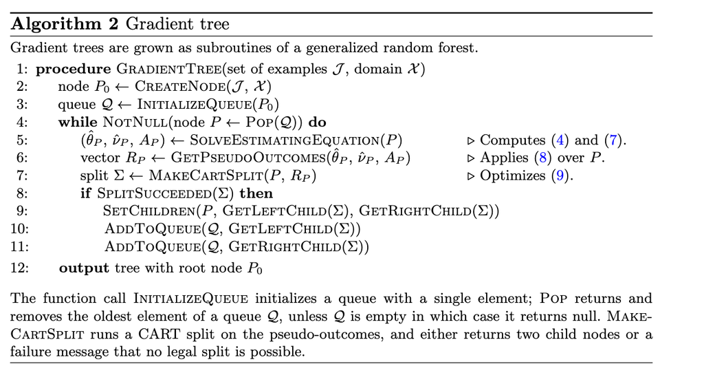

**The Generalized Random Forest Algorithm**

The generalized random forest consist of the steps mentioned in this section. First of all the for every tree a subsample for the training data is build which is splitted into two sets. One is the training set and the other one is the estimation set. Then for every sample the gradient tree is build based the training set. Afterthat, the weights are build according to the adaptive neighborhood method which gives at the end the output of $\hat{\theta}$ with the weights $\alpha$ divided by the amount of Trees B.

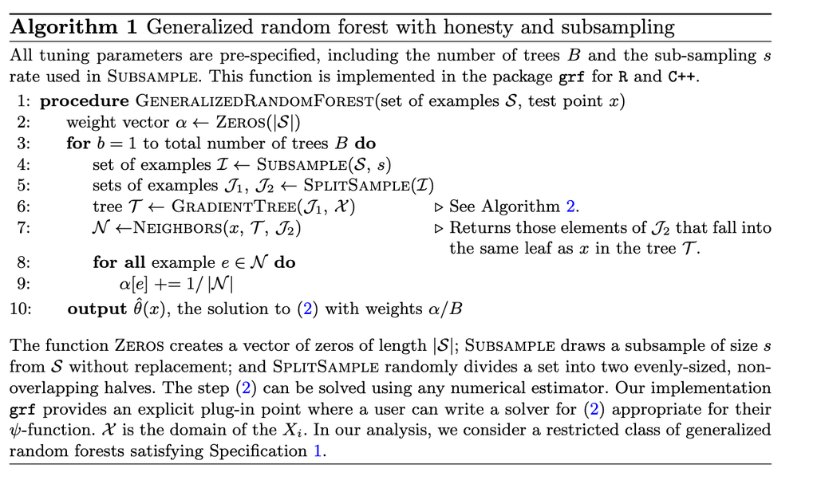

## Empirical work

After all of the technical knowledge is explained in this section we are going to see how the generalized random forest does in application. Therefore we used two types of data: real life data and synthetic data. To get a better overview of the performance of the algorithm we used as benchmark a two model approach based on random forest to get an directly comparison. Only the most important chunk of codes included in this notebook in order keep it clean and easly followable. The whole code can be viewed: [the notebook with all codes](https://colab.research.google.com/drive/10__8At4OYIgQZhCe7WJZpFZFJidYcy4L?usp=sharing)

### 1)Empirical Work With Real Life Data

In this part we want to use the generalized random forest algoritihm on real- life data, where the problem like for all real life causal relationship data is, that in comparison to other data it is not possible to observe the "ground truth". In other words, only one output can be observed, that means only the value of the treatment group or the control group can be observed. However, it is important to test a method on real world data based on the fact that in practice only they are used.

```python
#install.packages("readr")
library(readr)
#a=cat(read_file("http://www.biostat.jhsph.edu/~cfrangak/biostat_causal/asthma.txt"))
mydata=read.delim("http://www.biostat.jhsph.edu/~cfrangak/biostat_causal/asthma.txt",header = TRUE, sep = "", dec = ".")
```

```python
mydata=data.frame(mydata)
#summary(mydata)
head(mydata)
```

A data.frame: 6 × 11

|  | pg <int> | i.age <int> | i.sex <int> | i.educ <int> | i.insu <int> | i.drug <int> | i.seve <int> | com.t <int> | pcs.sd <dbl> | mcs.sd <dbl> | i.aqoc <int> |
| --- | --- | --- | --- | --- | --- | --- | --- | --- | --- | --- | --- |
| 1 | 1 | 36 | 0 | 5 | 1 | 1 | 2 | 4 | 49.97533 | 49.57280 | 1 |
| 2 | 1 | 37 | 1 | 6 | 2 | 1 | 3 | 3 | 40.93979 | 56.11393 | 1 |
| 3 | 1 | 43 | 1 | 5 | 1 | 1 | 4 | 3 | 50.32495 | 57.11961 | 1 |
| 4 | 1 | 39 | 1 | 6 | 1 | 1 | 4 | 1 | 49.34402 | 49.65159 | 1 |
| 5 | 1 | 46 | 1 | 1 | 2 | 1 | 4 | 0 | 37.37425 | 52.95411 | 0 |
| 6 | 1 | 40 | 1 | 3 | 1 | 1 | 3 | 2 | 40.56052 | 50.66690 | 0 |

The data we chose comes from a study to figure out the quality of services provided by two physican groups (1,2). According to these groups we will estimate the heterogeneous treatment effect whe group 1 will be the control group and group 2 the treatment group.

Variables: pg:Treatment assignment-binary(the data will be arranged accordingly)

i.age: age-continous

i.sex: sex-binary

i.educ: education-categorical

i.insu: insurance status-categorical

i.drug: drug coverage status-binary

i.seve: severity-categorical

com.t: total number of comorbidity-categorical

pcs.sd: standart physical comorbidity scale- continous

mcs.sd: standart mental comorbidity scale-continous

i.aqoc: output-satisfaction status of patient-binary

The first model will be basic generalized random forest model consisting of 500 trees. In order to implement the generalized random forest approach the R package of grf in CRAN is used.

```python
#install.packages("grf")
library(grf)
```

```python
install.packages("caTools")
require(caTools)
set.seed(101)
#splitting the data into training and test set
sample = sample.split(mydata, SplitRatio = .80)
train = subset(mydata, sample == TRUE)
test  = subset(mydata, sample == FALSE)
```

```python
#creating grf
tau.forest =causal_forest(X_train, Y_train, W_train, num.trees = 500)
tau.hat = predict(tau.forest, X_test, estimate.variance = TRUE)
```

```python
variable_importance(tau.forest)
```

A matrix: 19 × 1 of type dbl

| 0.118551451 |
| --- |
| 0.006342565 |
| 0.000000000 |
| 0.025370258 |
| 0.011099488 |
| 0.017929307 |
| 0.003171282 |
| 0.003171282 |
| 0.000000000 |
| 0.000000000 |
| 0.006342565 |
| 0.041102791 |
| 0.000000000 |
| 0.000000000 |
| 0.003171282 |
| 0.033298464 |
| 0.029028795 |
| 0.237350658 |
| 0.342118593 |

In the real data, output is binary, however the model estimates the treatment effect as continous variable. In this case, treatment effect estimation is perceived as percentage change in the possibility to have output variable equal to 1 in case of the treatment. This approach will be maintained among this experiment.

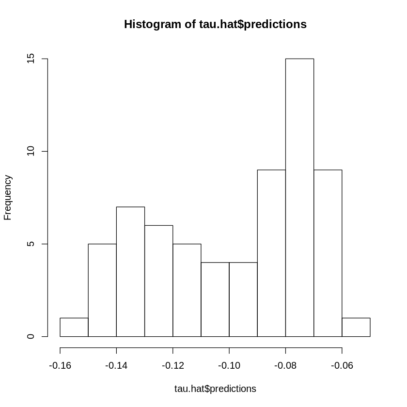

```python
hist(tau.hat$predictions)
```

**Figure 1:** The histogram shows the distribution of the treatment effect predictions by generalized random forest. The most interesting part is that predictions are all negative, this means that the first physican is giving better performance according to generalized random forest model which is true on the real data in terms of average. The distribution of CATE is skewed towards the right of the space. As it can be seen from the histogram, the small amount of the predictions are made in extreme values on the edges. That is a characteristic of the algorithm which is also discussed in the main paper.

```python
summary(tau.hat$predictions)
```

```
    Min.  1st Qu.   Median     Mean  3rd Qu.     Max.
-0.15005 -0.12500 -0.08583 -0.09781 -0.07450 -0.05793
```

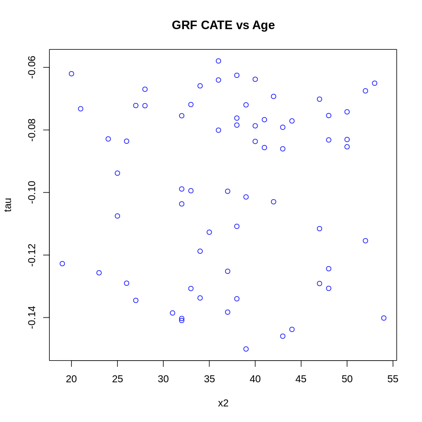

```python
plot(X_test[, 1], tau.hat$predictions,  xlab = "x2", ylab = "tau",main="GRF CATE vs Age",col="blue")
```

**Two Model Approach with Real Life Data**

Two model approach with random forest is the model used for the comparison of model behaviors on real life data. Two model approach is commonly used in the literature of uplift modeling. It is intuitive and easy to implement. Basically the process of training data is partioned into two parts: treated observations and control observations. Then two seperate models are trained according to those partioned observations. Afterthat, the test data is plugged on both of the models and the treatment effect on test data is calculated by tje as difference of the predictions between the observations of the treated and the observations of the control model.

```python
rf1=randomForest(X_train_treated,y=Y_train_treated,ntree=100,mtry=3,replace=TRUE)
rf1.prediction=predict (rf1,X_test,type = "prob")[,2]
#rf1.prediction
rf0=randomForest(X_train_control,y=Y_train_control,ntree=100,mtry=3,replace=TRUE)
rf0.prediction=predict (rf0,X_test,type = "prob")[,2]
#rf0.prediction
tau_rf=rf1.prediction-rf0.prediction
#tau_rf
```

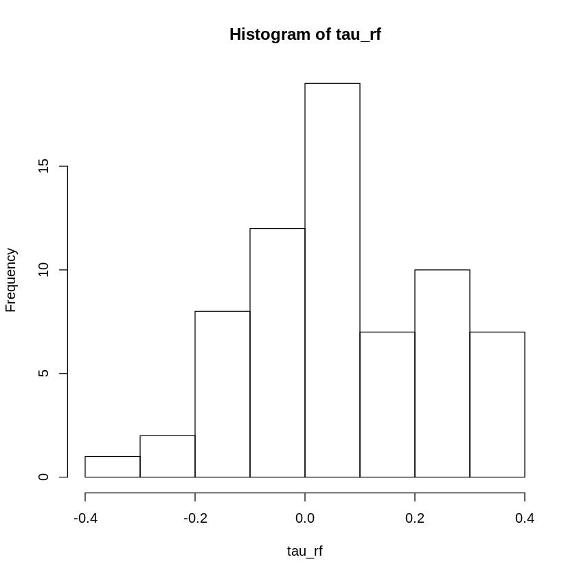

```python
hist(tau_rf)
```

```python
summary(tau_rf)
```

```
   Min. 1st Qu.  Median    Mean 3rd Qu.    Max.
-0.3400 -0.0400  0.0700  0.0697  0.2050  0.3800
```

```python
importance(rf1)
importance(rf0)
```

A matrix: 19 × 1 of type dbl

|  | MeanDecreaseGini |
| --- | --- |
| i.age | 2.58437958 |
| i.sex | 0.72927562 |
| i.educ.3 | 0.22590824 |
| i.educ.4 | 0.99250784 |
| i.educ.5 | 0.55997626 |
| i.educ.6 | 0.39207690 |
| i.insu.1 | 0.56988436 |
| i.insu.2 | 0.45049969 |
| i.insu.4 | 0.02777045 |
| i.seve.1 | 0.34724691 |
| i.seve.2 | 0.48733480 |
| i.seve.3 | 0.57141012 |
| i.seve.4 | 0.55622526 |
| com.t.1 | 0.04596484 |
| com.t.2 | 0.63210894 |
| com.t.3 | 0.41765194 |
| com.t.4 | 0.68017096 |
| pcs.sd | 3.17644814 |
| mcs.sd | 3.49099466 |

A matrix: 19 × 1 of type dbl

|  | MeanDecreaseGini |
| --- | --- |
| i.age | 6.8839864 |
| i.sex | 1.8584368 |
| i.educ.3 | 0.3711839 |
| i.educ.4 | 1.4824931 |
| i.educ.5 | 1.0429290 |
| i.educ.6 | 1.1328776 |
| i.insu.1 | 0.9800406 |
| i.insu.2 | 0.9312605 |
| i.insu.4 | 0.3893197 |
| i.seve.1 | 1.5454617 |
| i.seve.2 | 1.2732737 |
| i.seve.3 | 1.4374613 |
| i.seve.4 | 1.2324707 |
| com.t.1 | 0.7527660 |
| com.t.2 | 1.6362815 |
| com.t.3 | 1.2900511 |
| com.t.4 | 1.0117650 |
| pcs.sd | 7.5972259 |
| mcs.sd | 7.9600373 |

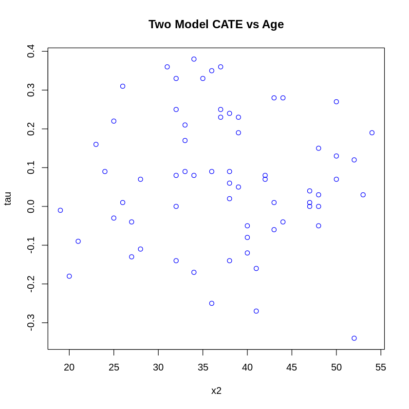

```python
plot(X_test[, 1], tau_rf,  xlab = "x2", ylab = "tau",main="Two Model CATE vs Age",col="blue")
```

```python
#grf prediction summary
summary(tau_rf)
#two model approach prediction summary
summary(tau.hat$predictions)
```

```
   Min. 1st Qu.  Median    Mean 3rd Qu.    Max.
-0.3400 -0.0400  0.0700  0.0697  0.2050  0.3800
```

```
    Min.  1st Qu.   Median     Mean  3rd Qu.     Max.
-0.15005 -0.12500 -0.08583 -0.09781 -0.07450 -0.05793
```

### 2)Empirical Work with Synthetic Data

So far only the empirical work with real life data is implemented. Although it is very important to see how the model performs under the real life conditions and examine predicition behaviour, there is a big constraint working with real life data. Since it is impossible to observe both treatment and control case for the same point, it is impossible to know the real treatment effect. This leads to lack of metric evaluation of the model and comparing it with a benchmark in terms of some numeric measurument criteria. Therefore, synthetic data is required for such an evaluation. Synthetic data will be created both in cases of confoundness and no confoundness as in main paper in order to detect model behvaiour under the violation of confounding assumption and test orthognalization helps in this case.

Distributions:

X~U(0,1)

Yi| Xi, Wi ∼ N (X4+m(Xi) + (Wi)*sigmoid(0.5+X1)*sigmoid(0.5+X2), 1)

Wi|Xi ∼ Bernoulli(e(Xi))

m(x)=3X3+2 it is the base average,m(x)=0 with no-confounding

e(x)=X3,e(x)=0.5 with no confounding

case1:no confoundness p1(number of features)=10,n1=1000

```python
sigmoid <- function(x) {
exp(x)/(1+exp(x))
}
```

```python
#training set creation
n1=1000
p1=10
set.seed(107)
X =matrix(runif(n1 * p1), n1, p1)
install.packages("Rlab")
library(Rlab)

W=rbinom(n=n1,size=1,prob=0.5)
Y=matrix(0, n1, 1)

for (i in 1:n1){
  Y[i]=rnorm(n=1,mean =X[i,4]+W[i]*sigmoid(0.5+X[i,1])*sigmoid(0.5+X[i,2]),sd=1)
}
```

```python
#TEST SET CREATION
set.seed(108)
n1_test=200
X_test =matrix(runif(n1_test * p1), n1_test, p1)
```

```python
#creating the grf
tau.forest =causal_forest(X, Y, W, num.trees = 3000)
tau.hat = predict(tau.forest, X_test, estimate.variance = TRUE)
```

```python
variable_importance(tau.forest)
```

A matrix: 10 × 1 of type dbl

| 0.12916519 |
| --- |
| 0.05232007 |
| 0.06781855 |
| 0.09062445 |
| 0.21277412 |
| 0.08623203 |
| 0.10484151 |
| 0.08658940 |
| 0.09060376 |
| 0.07903093 |

Generalized Random forest succeeded to detect that the first variable is important on treatment effect estimation.However, it fails to detect that the importance of X2 on treatment effect. Instead, it gave a huge importance to X5 which is totally irrelevant. This can be due to random nature of Y,X and W. The fine tuned version will be investigated

```python
tau.forest =causal_forest(X, Y, W, num.trees = 3000)
tau.hat = predict(tau.forest, X_test, estimate.variance = TRUE,tune.parameters=TRUE)
```

```python
variable_importance(tau.forest)
```

A matrix: 10 × 1 of type dbl

| 0.13317067 |
| --- |
| 0.06252398 |
| 0.06777584 |
| 0.09546665 |
| 0.20126770 |
| 0.08994898 |
| 0.09850093 |
| 0.08741093 |
| 0.08621790 |
| 0.07771641 |

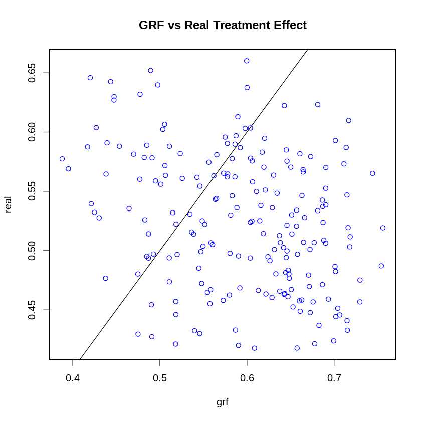

```python
#creating real treatment effect variable and then plot the relationship
treatment_test=sigmoid(0.5+X_test[,1])*sigmoid(0.5+X_test[,2])
plot(tau.hat$predictions, treatment_test,  xlab = "grf", ylab = "real",main="GRF vs Real Treatment Effect",col="blue")
abline(a=0,b=1)
```

The graph above shows the realtionship of real treatment effect versus generalized random forest`s predictions. Theoretically they should be fitted in the line with the slope of 1 and the intercept is 0. However most of the points are distributed outside of this line.

```python
#two model approach
selectedindexes=which(W==1)
#selectedindexes
#3mean (W)
X.treated=X[selectedindexes,]
Y.treated=Y[selectedindexes]
X.control=X[-selectedindexes,]
Y.control=Y[-selectedindexes]
rf1=randomForest(X.treated,y=Y.treated,ntree=3000,mtry=3,replace=TRUE,type="regression")
rf1.prediction=predict (rf1,X_test)
rf1.prediction
rf0=randomForest(X.control,y=Y.control,ntree=3000,mtry=3,replace=TRUE,type="regression")
rf0.prediction=predict (rf0,X_test)
rf0.prediction
tau.rf=rf1.prediction-rf0.prediction
```

```python
importance(rf1)
importance(rf0)
```

A matrix: 10 × 1 of type dbl

|  | IncNodePurity |
| --- | --- |
| 1 | 48.01291 |
| 2 | 47.47754 |
| 3 | 46.09375 |
| 4 | 81.66946 |
| 5 | 51.23163 |
| 6 | 49.31626 |
| 7 | 50.15950 |
| 8 | 45.62971 |
| 9 | 44.50801 |
| 10 | 41.13974 |

A matrix: 10 × 1 of type dbl

|  | IncNodePurity |
| --- | --- |
| 1 | 45.78694 |
| 2 | 46.39610 |
| 3 | 48.33362 |
| 4 | 79.76088 |
| 5 | 50.23356 |
| 6 | 54.66226 |
| 7 | 46.00111 |
| 8 | 58.26127 |
| 9 | 54.24954 |
| 10 | 47.89586 |

When the importance of the variables are observed, it can be easily concluded that the fourth variable is the most important on the control and treatment mean estimation. That is normal when we consider the fourth variable is effecting the bias.

With fine tuning, the importance of the first two variables are increased, which follows a better opportunity to channel the model into the direction of the true treatment effect.

As it is mentioned before, two model approach with random forest is used as a benchmark to compare the metrics of the results. MSE in treatment effect in test data will be used as a comparison metric, since the grand true distribution of real treatment effect is already known.

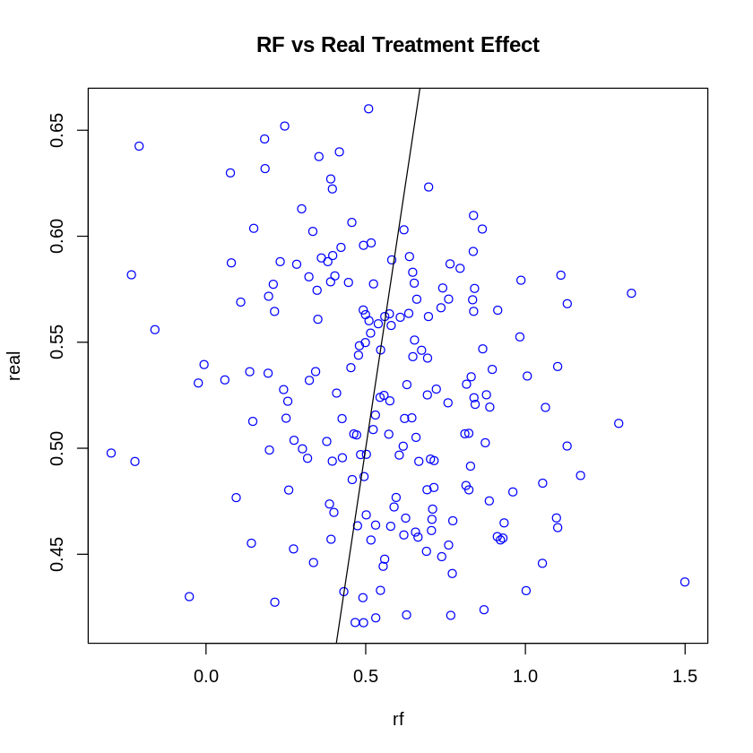

```python
plot(tau.rf, treatment_test,  xlab = "rf", ylab = "real",main="RF vs Real Treatment Effect",col="blue")
abline(a=0,b=1)
```

### Local Centering

In the case of confoundness, one of the main assumptions of the model is violated and treatment assignment is not completely independent of Y and X. In such a case, the main paper recommends local centering. Local centering is simply centerelizing variable W and the outcome Y seperately, by substracting the conditional expectations on X. In order to apply this process, the main paper recommends a procedure of regressing Y and W on X to produce leave-one estimation of each point of Yi and Wi. As it is mentioned in main paper, there are some similar concepts to find a solution for confoundness such as orthogonalization such as [Chernozhukov et al,2016](https://arxiv.org/pdf/1608.00060.pdf) and [Robinson 1988](https://www.jstor.org/stable/1912705?seq=1#metadata_info_tab_contents). We include generalized random forest model with local centering in order to see that it helps the quality of the predictions under confoundness. The application of local centering in grf package the approach the work of [Susan Athey et al,2019](https://arxiv.org/pdf/1902.07409.pdf#page=14&zoom=100,81,752) is used.

Case 4 with centeralized grf

```python
n4=1000
p4=10
set.seed(130)
X =matrix(runif(n4 * p4), n4, p4)

W= matrix(0, n4, 1)
for (i in 1:n4){
  W[i]=rbinom(n=1,size=1,prob=X[i,3])
}

Y=matrix(0, n4, 1)

for (i in 1:n4){
  Y[i]=rnorm(n=1,mean =X[i,4]+W[i]*sigmoid(0.5+X[i,1])*sigmoid(0.5+X[i,2]),sd=1)
}
```

```python
#TEST SET CREATION
set.seed(131)
n4_test=200
X_test =matrix(runif(n4_test * p4), n4_test, p4)
```

```python
treatment_test=sigmoid(0.5+X_test[,1])*sigmoid(0.5+X_test[,2])
```

```python
Y.forest=regression_forest(X,Y)
Y.hat=predict(Y.forest)$predictions
W.forest=regression_forest(W,Y)
W.hat=predict(W.forest)$predictions
centerilzed_grf = causal_forest(X, Y, W , Y.hat =Y.hat , W.hat=W.hat, num.trees = 3000)
tau.hat = predict(centerilzed_grf, X_test, estimate.variance = TRUE,tune.parameters=TRUE)
```

```python
#creating the data frame for mse performances
conf=c("no","no","no","yes","yes","yes")
p=c(10,10,20,10,10,20)
n=c(1000,2000,1000,1000,2000,1000)
mse_rf=c(format(round(mse.rf1*10, 2), nsmall = 2),format(round(mse.rf2*10, 2), nsmall = 2),
format(round(mse.rf3*10, 2), nsmall = 2),format(round(mse.rf4*10, 2), nsmall = 2),
format(round(mse.rf5*10, 2), nsmall = 2),format(round(mse.rf6*10, 2), nsmall = 2))

mse_grf=c(format(round(mse.grf1*10, 2), nsmall = 2),format(round(mse.grf2*10, 2), nsmall = 2),
format(round(mse.grf3*10, 2), nsmall = 2),format(round(mse.grf4*10, 2), nsmall = 2),
format(round(mse.grf5*10, 2), nsmall = 2),format(round(mse.grf6*10, 2), nsmall = 2))

mse_c_grf=c("-","-","-",
format(round(mse.grf_centerilzed4*10, 2), nsmall = 2),
format(round(mse.grf_centerilzed5*10, 2), nsmall = 2),format(round(mse.grf_centerilzed6*10, 2), nsmall = 2))
mytable= data.frame(conf,p,n,mse_rf,mse_grf,mse_c_grf)
mytable
```

A data.frame: 6 × 6

| conf <fct> | p <dbl> | n <dbl> | mse_rf <fct> | mse_grf <fct> | mse_c_grf <fct> |
| --- | --- | --- | --- | --- | --- |
| no | 10 | 1000 | 1.03 | 0.18 | - |
| no | 10 | 2000 | 1.02 | 0.04 | - |
| no | 20 | 1000 | 0.41 | 0.05 | - |
| yes | 10 | 1000 | 0.74 | 0.18 | 2.52 |
| yes | 10 | 2000 | 0.92 | 0.10 | 3.50 |
| yes | 20 | 1000 | 0.82 | 0.15 | 8.23 |

## Future Work

One work which is based on the generalized random forest is the orthogonal random forest for causal inference by Oprescu & Syrgkanis & Wu (2019). This algorithm combines Neyman-orthogonality to reduce sensitivity with respect to estimation error of nuisance parameters with generalized random forest. Based on this paper it is possible to create results with the same error rate as an oracle with priori knowledge of the nuisance parameters. The main approach of the Orthogonal Forest is the combination of Neyman orthognality of the moment equations, the generalized random forest and the double machine learning approach. Therefore, the algorithm first follows the residual-on-residual regression approach to formulate a locally Neyman orthogonal moment where the orthogonal forest algorithm is applied to the orthogonal moment. This approach comes near to the “local centering” which is mentioned in the paper Athey & Tibshirani & Wager(2018) about generalized random forest.

## Conclusion

In this notebook we presented a method for conditional averaging treatment effect (CATE) estimation called Generalized Random Forest. This method is based on the approach of causal tree and causal forest. In the accordingly paper of Athey & Imbens (2016) it is mentioned that causal tree and causal forest enables an estimation of heterogeneous causal effects with a valid confidence intervals for treatment effects and they mentioned that through the model selection criterion the bias can be eliminated through honest estimation. Therefore, the term "honest" is introduced as a new method of dealing with data samples and the splitting criteria is changed such as that the tree not partition on the output but on the treatment effect. This has the effect that partitions are found which find strong heterogeneity in treatment effect. The Generalized random forest used this as basic and build unbiased estimation for heterogeneous treatment effect. In relation to forest they build a splitting criteria based on the assumptions and used the adaptive neighborhod as an approach to set weights to the data points such as not only the data points who are in the same leaf of a tree are used but all. In the second part of our notebook the generalized random forest was used on real life data and synthetic data in comparison with the random forest which was introduced by Breimann (2001). It leads to the result that in estimating treatment effects the generalized random forest does a better job whereas we tried to improve the results by centralization failed. All in all, generalized random forest is a relatively new effective approach to estimate heterogeneous treatment effect which is also used as basic for other new studies such as orthogonal random forest.

## References

**Main Reference**

Athey, S., Tibshirani, J., & Wager, S. (2019). Generalized random forests. The Annals of Statistics, 47(2), 1148-1178.

**Other References**

Athey, S., & Wager, S. (2019). Estimating treatment effects with causal forests: An application. arXiv preprint arXiv:1902.07409.

Breiman, L. (2001). Random forests. Machine learning, 45(1), 5-32.

Chernozhukov, V., Chetverikov, D., Demirer, M., Duflo, E., Hansen, C., Newey, W., & Robins, J. (2018). Double/debiased machine learning for treatment and structural parameters.

Oprescu, M., Syrgkanis, V., & Wu, Z. S. (2019, May). Orthogonal random forest for causal inference. In International Conference on Machine Learning (pp. 4932-4941).

Robinson, P. M. (1988). Root-N-consistent semiparametric regression. Econometrica: Journal of the Econometric Society, 931-954.

Rosenbaum, P. R., & Rubin, D. B. (1983). The central role of the propensity score in observational studies for causal effects. Biometrika, 70(1), 41-55.

Wager, S., & Athey, S. (2018). Estimation and inference of heterogeneous treatment effects using random forests. Journal of the American Statistical Association, 113(523), 1228-1242.

Xie, Y., Brand, J. E., & Jann, B. (2012). Estimating heterogeneous treatment effects with observational data. Sociological methodology, 42(1), 314-347.